# INTERMEDIATE R: FUNCTIONS

### 3.1 Introduction to functions

We already know some built-in functions in R. For example, create a list with `list()`, or display a variable with `print()` function.

Functions work like a black box. You give an input to a black box, it processes the input and returns an output.

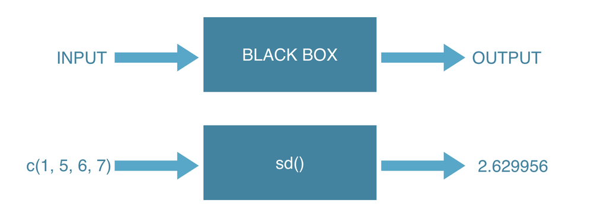

- Statistical function, like `sd()` for standard deviation:

```r
sd(c(1, 5, 6, 7))
```

```
## [1] 2.629956
```

Specify function arguments inside `()`.

Assign the input vector to a variable, then call `sd()` function:

```r
values <- c(1, 5, 6, 7)
sd(values)
```

```
## [1] 2.629956
```

Assign the result of the function to a variable to reuse it:

```r
my_sd <- sd(values)
```

- Function documentation: `help(sd)` or `?sd` (look up in the function documentation for more info).

The syntax of `sd()` could be found in the help page: `sd(x, na.rm = FALSE)`  
R matches the values to the `x` argument by position or by name: `sd(x = values)`

- `na.rm` argument is a logical value indicating whether or not missing values should be removed.

```r
values <- c(1, 5, 6, 7, NA)
sd(values)
```

```
## [1] NA
```

Set `na.rm` argument to `TRUE`:

```r
sd(values, TRUE) # or matching by name
```

```
## [1] 2.629956
```

```r
sd(values, na.rm = TRUE)
```

```
## [1] 2.629956
```

`sd()` will return an error if there’s no argument is specified.

- `args()`: to learn about the arguments of a function without having to go through the entire document.

```r
args(sd)
```

```
## function (x, na.rm = FALSE)
## NULL
```

Before using an R function, you should clarify which arguments it expects.

Consult the documentation on the `mean()` function: `?mean`

```r
args(mean)  # inspect the arguments.
```

```
## function (x, ...)
## NULL
```

Continue with the exercise on the views on social media:

```r
linkedin <- c(16, 9, 13, 5, 2, 17, 14)
facebook <- c(17, 7, 5, 16, 8, 13, 14)
```

Calculate average number of views:

```r
(avg_lin <- mean(linkedin))
```

```
## [1] 10.85714
```

```r
(avg_fb <- mean(facebook)) # put the variable inside the parenthese will print it out in the console.
```

```
## [1] 11.42857
```

Calculate the `mean` of the sum:

```r
(avg_sum <- sum(mean(linkedin), mean(facebook)))
```

```
## [1] 22.28571
```

```r
(avg_trimmed <- mean(linkedin + facebook, trim = 0.2))
```

```
## [1] 22.6
```

The use of a trimmed mean helps eliminate the influence of outliers or data points on the tails that may unfairly affect the traditional mean.

Suppose there’re missing values in the view record:

```r
linkedin <- c(16, 9, 13, 5, NA, 17, 14)
facebook <- c(17, NA, 5, 16, 8, 13, 14)
```

To calculate the average view using `mean()`, set `na.rm() = TRUE`:

```r
mean(linkedin, na.rm = TRUE)
```

```
## [1] 12.33333
```

Calculate the mean absolute function:

```r
mean(abs(linkedin - facebook), na.rm = TRUE) # Functions inside functions!
```

```
## [1] 4.8
```

### 3.2 Writing functions

A *function* typically serves a particular need or solves a particular problem, without having to care about how the function does this. R allows to write your own function and use it as a standard function like `sd()`, `mean()`…

The syntax for writing a funtion:  
`my_func <- function(arg1, arg2) {` (create a new function)  
`body` (create a function that takes arguments arg1 and arg2)  
`}` (performs the code in the body on these arguments).

Define a function that calculates the triple of its input, called `triple`:

```r
triple <- function(x) { # x represents input as a number
  3*x                   # calculates the triple of x.
}
```

Check if the new object is already defined in the workspace:

```r
ls() # list the object "triple".
```

```
## [1] "avg_fb"      "avg_lin"     "avg_sum"     "avg_trimmed" "facebook"
## [6] "linkedin"    "my_sd"       "triple"      "values"
```

Calculate the triple of 6:

```r
triple(6) # numeric 6 matched to argument(x)
```

```
## [1] 18
```

```r
          # function body is executed: 3 * 6
          # last expression evaluated becomes the return value.
```

- `return()` statement: explicitly specify the return value.

```r
triple <- function(x) {
  y <- 3*x
  return(y)
}         # returns the same result.
```

Using a `return` statement at the end of the function is not always useful, but there are other cases where it becomes handy.

R passes arguments by value.

```r
a <- 5
triple(a)
```

```
## [1] 15
```

```r
a
```

```
## [1] 5
```

The R objects you pass to a function can never change unless you do an explicit assignment.

```r
increment <- function(x, inc = 1) {
  x <- x + inc
  x
}
count <- 5
a <- increment(count, 2)
b <- increment(count)
count <- increment(count, 2)
```

R passes arguments by *value* and not by *reference*, the value of count is not changed after the first two calls of `increment()`. Only in the final expression, where count is re-assigned explicitly, does the value of `count` change.

Write a function called `math_magic()` that takes two numbers as input and calculates the sum of the product and the division of both numbers:

```r
math_magic <- function(a, b) {
  a*b + a/b
}
```

Sourcing the new function with numbers 4 and 2:

```r
math_magic(4,2)
```

```
## [1] 10
```

R will return an error if the input has only one argument: `math_magic(4)`

Making the second argument optional:

```r
math_magic <- function(a, b = 1) { # adding default value.
  a*b + a/b
}
```

Sourcing the function again:

```r
math_magic(4) # because argument b is not specified, R set it to default value that equals 1.
```

```
## [1] 8
```

Call `math_magic()` with numbers 4 and 0:

```r
math_magic(4,0) # result is Inf, or infinity, because 4/0 = inf
```

```
## [1] Inf
```

Extend the function with an *if-return* statement to guard the function agains this misuse:

```r
math_magic <- function(a, b = 1){
  if(b == 0){
    return(0)
  }
  a*b + a/b
}
```

Recall the function again:

```r
math_magic(4,0) # return statement can halt the execution anytime.
```

```
## [1] 0
```

Create a function that takes two arguments and returns the sum of the absolute values of both arguments:

```r
sum_abs <- function(a, b){
  abs(a) + abs(b)
}
sum_abs(-2, 3)
```

```
## [1] 5
```

There are situations in which the function does not require an input. For example, write a function that gives the random outcome of throwing a fair die:

```r
throw_die <- function(){
  number <- sample(1:6, size = 1)
  number
}
throw_die()
```

```
## [1] 5
```

Define a function without argument that prints out “Hi there!” and returns `TRUE`:

```r
hello <- function(){
  print("Hi there!")
  return(TRUE)
}
hello()
```

```
## [1] "Hi there!"
```

```
## [1] TRUE
```

Create a function that takes one argument and returns that number squared:

```r
power_two <- function(x){
  x^2
}
```

Add an optional argument named `print_info`, that is `TRUE` by default and and `if` statement.

```r
power_two <- function(x, print_info = TRUE){
  y <- x^2
  if(print_info){
    print(paste(x, "to the power two equals", y))
  }
  return(y)
}
```

Call the newly defined function with different inputs:

```r
power_two(5)
```

```
## [1] "5 to the power two equals 25"
```

```
## [1] 25
```

```r
power_two(5, FALSE)
```

```
## [1] 25
```

```r
power_two(5, TRUE)
```

```
## [1] "5 to the power two equals 25"
```

```
## [1] 25
```

- Function scoping: variables that are defined inside a function are not accessible outside that function.

```r
two_dice <- function(){
  possibilities <- 1:6
  dice1 <- sample(possibilities, size = 1)
  dice2 <- sample(possibilities, size = 1)
  dice1 + dice2
} # whatever the way of calling the two_dice() function, R won't have the access to dice1 and dice2 outside of the function.
```

Continue the exercise with the record of social media views in `linkedin` and `facebook`:

```r
linkedin <- c(16, 9, 13, 5, 2, 17, 14)
facebook <- c(17, 7, 5, 16, 8, 13, 14)
```

Write a function that interprets the view of a singe record day:

```r
interpret <- function(num_views) {
  if (num_views > 15) {
    print("You're popular!")
    return(num_views)
  } else {
    print("Try to be more visible!")
    return(0)
  }
}
```

Call the interpret function twice:

```r
interpret(linkedin[1])
```

```
## [1] "You're popular!"
```

```
## [1] 16
```

```r
interpret(linkedin[2])
```

```
## [1] "Try to be more visible!"
```

```
## [1] 0
```

Now write a function that interprets all the data from the daily views. Make `return_sum` an optional argument, that is `TRUE` by default.

```r
interpret_all <- function(views, return_sum = TRUE) {
  count <- 0
  for (v in views) {
    count <- count + interpret(v)
  }
  if (return_sum) {
    return(count)
  } else {
    return(NULL)
  }
}
```

Call the `interpret_all()` function on both `linkedin` and `facebook`.

```r
interpret_all(linkedin)
```

```
## [1] "You're popular!"
## [1] "Try to be more visible!"
## [1] "Try to be more visible!"
## [1] "Try to be more visible!"
## [1] "Try to be more visible!"
## [1] "You're popular!"
## [1] "Try to be more visible!"
```

```
## [1] 33
```

```r
interpret_all(facebook)
```

```
## [1] "You're popular!"
## [1] "Try to be more visible!"
## [1] "Try to be more visible!"
## [1] "You're popular!"
## [1] "Try to be more visible!"
## [1] "Try to be more visible!"
## [1] "Try to be more visible!"
```

```
## [1] 33
```

### 3.3 Anonymous functions

Functions in R are *objects* in their own right. This means that they aren’t automatically bound to a name. When you create a function, you can use the assignment *operator* to give the function a name. It’s perfectly possible, however, to not give the function a name. This is called an *anonymous function*.

- Named function:

```r
triple <- function(x) { 3 * x }
```

- Anonymous function with same implementation

```r
function(x) { 3 * x }
```

```
## function(x) { 3 * x }
```

Anonymous functions are helpful when you need to use the function only once, avoid defining it with a name.